# Analysis of Multiple-Causes Tracking Scenario (Study 1b)

Anonymous

# 1 Participant Exclusion

> Number of flat responders:

```r
# number of flat responders
sum(ecl_dat$flat)
```

```
## [1] 2
```

```r
# remove flat responders
ecl_dat <- ecl_dat[!ecl_dat$flat, ]
```

> Number of participants who failed first attention check:

```r
# number who failed attention1 check
sum(ecl_dat$attention1 != 2)
```

```
## [1] 3
```

```r
# remove those who failed attention1 check
ecl_dat <- ecl_dat[ecl_dat$attention1=="2",]
```

> Number of participants who failed second attention check:

```r
# number who failed attention2 check
sum(!(ecl_dat$attentionOrange == 0 & ecl_dat$attentionBlue == 0 & ecl_dat$attentionBulb == 1))
```

```
## [1] 22
```

```r
pass_attention2 <- (ecl_dat$attentionOrange == 0 & ecl_dat$attentionBlue == 0 & ecl_dat$attentionBulb == 1)
# remove those who failed attention2 check
ecl_dat <- ecl_dat[pass_attention2, ]
```

> Number of outliers for total time taken:

```r
# outlier for Total Time taken for survey
rt_range <- 3*sd(ecl_dat$totalRT)
slow <- which(ecl_dat$totalRT > mean(ecl_dat$totalRT,na.rm = T) + rt_range)
fast <- which(ecl_dat$totalRT < mean(ecl_dat$totalRT,na.rm = T) - rt_range)

# number of outliers for Total Time taken for survey
length(slow)
```

```
## [1] 1
```

```r
length(fast)
```

```
## [1] 0
```

```r
# remove outliers
ecl_dat <- ecl_dat[-slow,]
```

> Number of participants who failed anti-bot verification:

```r
n_fails <- which(ecl_dat$nFails > 3)
# number who failed bot check (more than 3 times)
length(n_fails)
```

```
## [1] 0
```

> Number of remaining participants after data cleaning:

```r
# number of participants in each condition (after exclusions)
ecl_dat$condition <- relabel(ecl_dat$condition,
                             from = c("condition 2","condition 1"),
                             to = c("no-emotion", "emotion"))
table(ecl_dat$condition)
```

```
##
##    emotion no-emotion
##         58         69
```

# 2 Summary Statistics

`relationXBlue`: likelihood that the blue box caused bulb to switch on. X indexes the measurement point (from 1 to 5) where the rating was collected from participants `relationXOrange` = likelihood that the orange box caused bulb to switch on. X indexes the measurement point (from 1 to 5) where the rating was collected from participants `relationXOrangeBlue` = likelihood that both boxes caused bulb to switch on. X indexes the measurement point (from 1 to 5) where the rating was collected from participants

```r
human_cause_data_t1 <- gather.keep(ecl_dat, var.to.gather = c("relation1BlueNorm", "relation1OrangeNorm", "relation1OrangeBlueNorm"), keep = c("id", "condition"), key = "structure",value="likelihood")

human_cause_data_t2 <- gather.keep(ecl_dat, var.to.gather = c("relation2BlueNorm", "relation2OrangeNorm", "relation2OrangeBlueNorm"), keep = c("id", "condition"), key = "structure",value="likelihood")

human_cause_data_t3 <- gather.keep(ecl_dat, var.to.gather = c("relation3BlueNorm", "relation3OrangeNorm", "relation3OrangeBlueNorm"), keep = c("id", "condition"), key = "structure",value="likelihood")

human_cause_data_t4 <- gather.keep(ecl_dat, var.to.gather = c("relation4BlueNorm", "relation4OrangeNorm", "relation4OrangeBlueNorm"), keep = c("id", "condition"), key = "structure",value="likelihood")

human_cause_data_t5 <- gather.keep(ecl_dat, var.to.gather = c("relation5BlueNorm", "relation5OrangeNorm", "relation5OrangeBlueNorm"), keep = c("id", "condition"), key = "structure",value="likelihood")
```

```r
set.seed(100)

human_cause_t1 <- human_cause_data_t1 %>% group_by(condition, structure) %>%
  multi_boot_standard(col="likelihood") %>%
  mutate(Structure = factor(structure, levels = c("relation1BlueNorm", "relation1OrangeNorm", "relation1OrangeBlueNorm"), labels = c("Blue Box", "Orange Box", "Both Boxes")))

human_cause_t2 <- human_cause_data_t2 %>% group_by(condition, structure) %>%
  multi_boot_standard(col="likelihood") %>%
  mutate(Structure = factor(structure, levels = c("relation2BlueNorm", "relation2OrangeNorm", "relation2OrangeBlueNorm"), labels = c("Blue Box", "Orange Box", "Both Boxes")))

human_cause_t3 <- human_cause_data_t3 %>% group_by(condition, structure) %>%
  multi_boot_standard(col="likelihood") %>%
  mutate(Structure = factor(structure, levels = c("relation3BlueNorm", "relation3OrangeNorm", "relation3OrangeBlueNorm"), labels = c("Blue Box", "Orange Box", "Both Boxes")))

human_cause_t4 <- human_cause_data_t4 %>% group_by(condition, structure) %>%
  multi_boot_standard(col="likelihood") %>%
  mutate(Structure = factor(structure, levels = c("relation4BlueNorm", "relation4OrangeNorm", "relation4OrangeBlueNorm"), labels = c("Blue Box", "Orange Box", "Both Boxes")))

human_cause_t5 <- human_cause_data_t5 %>% group_by(condition, structure) %>%
  multi_boot_standard(col="likelihood") %>%
  mutate(Structure = factor(structure, levels = c("relation5BlueNorm", "relation5OrangeNorm", "relation5OrangeBlueNorm"), labels = c("Blue Box", "Orange Box", "Both Boxes")))
```

```r
library(psych)

key_variables1 <- c("relation1BlueNorm", "relation1OrangeNorm", "relation1OrangeBlueNorm",
                    "relation2BlueNorm", "relation2OrangeNorm", "relation2OrangeBlueNorm",
                    "relation3BlueNorm", "relation3OrangeNorm", "relation3OrangeBlueNorm",
                    "relation4BlueNorm", "relation4OrangeNorm", "relation4OrangeBlueNorm",
                    "relation5BlueNorm", "relation5OrangeNorm", "relation5OrangeBlueNorm")

# table1 <- ecl_dat[,key_variables1] %>%
#   describe()%>%
#   as.data.frame()%>%
#   select(n,mean,sd,median,min,max,skew,kurtosis)
# knitr::kable(table1)
```

# 3 Demographics

> Gender of participants:

```r
table(ecl_dat$gender)
```

```
##
## Female   Hide   Male  Other
##     57      1     55      3
```

> Proportion of females amongst participants:

```r
# proportion of females
table(ecl_dat$gender)[[1]]/length(ecl_dat$gender)
```

```
## [1] 0.4488189
```

> Mean and SD for age amongst participants:

```r
mean(ecl_dat$age,na.rm = T)
```

```
## [1] 26.09483
```

```r
sd(ecl_dat$age,na.rm = T)
```

```
## [1] 8.683796
```

> Primary language of participants:

```r
table(ecl_dat$language)
```

```
##
##           Afrikaans           Bulgarian           Cantonese               Czech
##                   1                   1                   2                   1
##               Dutch     Dutch & English                 Eng             english
##                   1                   1                   1                   1
##             English             ENGLISH   English and Xhosa            estonian
##                  18                   2                   1                   1
##              French               greek               Greek           hungarian
##                   5                   1                   3                   2
##           Hungarian            IsiXhosa             IsiZulu             italian
##                   3                   1                   1                   1
##             Italian          lithuanian   Mandarin, English      Northern Sotho
##                   3                   1                   1                   1
##              polish              Polish          portuguese          Portuguese
##                   4                  23                   2                  17
##             Russian              Sepedi               Shona             Slovene
##                   1                   1                   1                   1
##           Slovenian               Sotho             spanish             Spanish
##                   1                   1                   2                  10
## Spanish abd English                Zulu
##                   1                   1
```

# 4 Comparing Model Predictions to Human Data

```r
human_cause_t1$time <- 1
human_cause_t2$time <- 2
human_cause_t3$time <- 3
human_cause_t4$time <- 4
human_cause_t5$time <- 5

human_tracking <- human_cause_t1 %>%
  full_join(human_cause_t2)%>%
  full_join(human_cause_t3)%>%
  full_join(human_cause_t4)%>%
  full_join(human_cause_t5)

human_tracking$Condition <- factor(human_tracking$condition,
                                   levels = c("emotion", "no-emotion"),
                                   labels = c("Emotion", "No Emotion"))

human_tracking$Structure <- factor(human_tracking$Structure,
                                   levels = c("Blue Box", "Orange Box", "Both Boxes"))

model_tracking = data.frame(
  Structure = c("Blue Box", "Orange Box", "Both Boxes",
                "Blue Box", "Orange Box", "Both Boxes",
                "Blue Box", "Orange Box", "Both Boxes",
                "Blue Box", "Orange Box", "Both Boxes",
                "Blue Box", "Orange Box", "Both Boxes",
                "Blue Box", "Orange Box", "Both Boxes",
                "Blue Box", "Orange Box", "Both Boxes",
                "Blue Box", "Orange Box", "Both Boxes",
                "Blue Box", "Orange Box", "Both Boxes",
                "Blue Box", "Orange Box", "Both Boxes"),
  condition = c("no-emotion", "no-emotion","no-emotion",
                "no-emotion", "no-emotion","no-emotion",
                "no-emotion", "no-emotion","no-emotion",
                "no-emotion", "no-emotion","no-emotion",
                "no-emotion", "no-emotion","no-emotion",
                "emotion", "emotion","emotion",
                "emotion", "emotion","emotion",
                "emotion", "emotion","emotion",
                "emotion", "emotion","emotion",
                "emotion", "emotion","emotion"),
  ci_lower = c(0.347, 0.283, 0.285,
               0.417975, 0.205   , 0.292 ,
               0.13 , 0.312, 0.475,
               0.079, 0.275, 0.566,
               0.018   , 0.293975, 0.622,
               0.352   , 0.278   , 0.281975,
               0.443, 0.185, 0.289,
               0.248975, 0.325   , 0.342,
               0.26 , 0.318, 0.335,
               0.076   , 0.405975, 0.438
               ),
  ci_upper = c(0.406, 0.336, 0.343,
               0.479, 0.255, 0.352,
               0.177, 0.372, 0.539,
               0.117, 0.334, 0.629,
               0.037025, 0.35    , 0.679025,
               0.41 , 0.335, 0.341,
               0.506, 0.235, 0.347,
               0.304, 0.381, 0.399,
               0.317, 0.377, 0.394,
               0.113   , 0.466025, 0.499
               ),
  mean = c(0.376,    0.310125, 0.313875,
           0.44825,  0.230125, 0.321625,
           0.15275, 0.34275, 0.5045,
           0.098125, 0.304375, 0.5975,
           0.0275, 0.3215, 0.651,
           0.380625, 0.30675 , 0.312625,
           0.474 ,   0.209375, 0.316625,
           0.277875 ,0.353,    0.369125,
           0.28775,  0.347875, 0.364375,
           0.0955 ,  0.436125, 0.468375
           ),
  time = c(1,1,1,
           2,2,2,
           3,3,3,
           4,4,4,
           5,5,5,
           1,1,1,
           2,2,2,
           3,3,3,
           4,4,4,
           5,5,5)
)

model_tracking$Condition <- factor(model_tracking$condition,
                                   levels = c("emotion", "no-emotion"),
                                   labels = c("Emotion", "No Emotion"))

model_tracking$Structure <- factor(model_tracking$Structure,
                                   levels = c("Blue Box", "Orange Box", "Both Boxes"))

human_tracking$Subject <- "Human"
model_tracking$Subject <- "Model"
cause_time_data <- full_join(human_tracking, model_tracking)
cause_time_data$time <- cause_time_data$time + c( rep(.1,30),  rep(-.1,30))
```

## 4.1 Correlation and Scatterplot

```r
cause_cor_data <- cause_time_data
cause_cor_data$time <- cause_cor_data$time -c( rep(.1,30),  rep(-.1,30))
cause_cor_data$id <- paste(cause_cor_data$Condition, cause_cor_data$Structure, cause_cor_data$time)

model_cor_data <- filter(cause_cor_data, Subject=="Model")
model_cor_data$pred <-  model_cor_data$mean
model_cor_data$pred_lower <-  model_cor_data$ci_lower
model_cor_data$pred_upper <-  model_cor_data$ci_upper
human_cor_data <- filter(cause_cor_data, Subject=="Human")
human_cor_data$actual <-  human_cor_data$mean
human_cor_data$actual_lower <-  human_cor_data$ci_lower
human_cor_data$actual_upper <-  human_cor_data$ci_upper

cor_data <- full_join(model_cor_data[,c("id","pred","Condition","pred_lower","pred_upper")],human_cor_data[,c("id","actual", "condition","actual_lower","actual_upper")], key="id")
# overall correlation
cor.test(cor_data$pred,cor_data$actual)
```

```
##
##  Pearson's product-moment correlation
##
## data:  cor_data$pred and cor_data$actual
## t = 5.9344, df = 28, p-value = 2.184e-06
## alternative hypothesis: true correlation is not equal to 0
## 95 percent confidence interval:
##  0.5281194 0.8721336
## sample estimates:
##       cor
## 0.7463788
```

This is the correlation comparing the human-ratings to model predictions for the emotion condition:

```r
# correlation within emotion condition
cor.test(cor_data$pred[cor_data$condition =="emotion"], cor_data$actual[cor_data$condition =="emotion"])
```

```
##
##  Pearson's product-moment correlation
##
## data:  cor_data$pred[cor_data$condition == "emotion"] and cor_data$actual[cor_data$condition == "emotion"]
## t = 7.004, df = 13, p-value = 9.286e-06
## alternative hypothesis: true correlation is not equal to 0
## 95 percent confidence interval:
##  0.6920365 0.9628387
## sample estimates:
##       cor
## 0.8891069
```

This is the correlation comparing the human-ratings to model predictions for the no-emotion condition:

```r
# correlation within no-emotion condition
cor.test(cor_data$pred[cor_data$condition =="no-emotion"], cor_data$actual[cor_data$condition =="no-emotion"])
```

```
##
##  Pearson's product-moment correlation
##
## data:  cor_data$pred[cor_data$condition == "no-emotion"] and cor_data$actual[cor_data$condition == "no-emotion"]
## t = 3.6289, df = 13, p-value = 0.003058
## alternative hypothesis: true correlation is not equal to 0
## 95 percent confidence interval:
##  0.3096385 0.8960347
## sample estimates:
##       cor
## 0.7093818
```

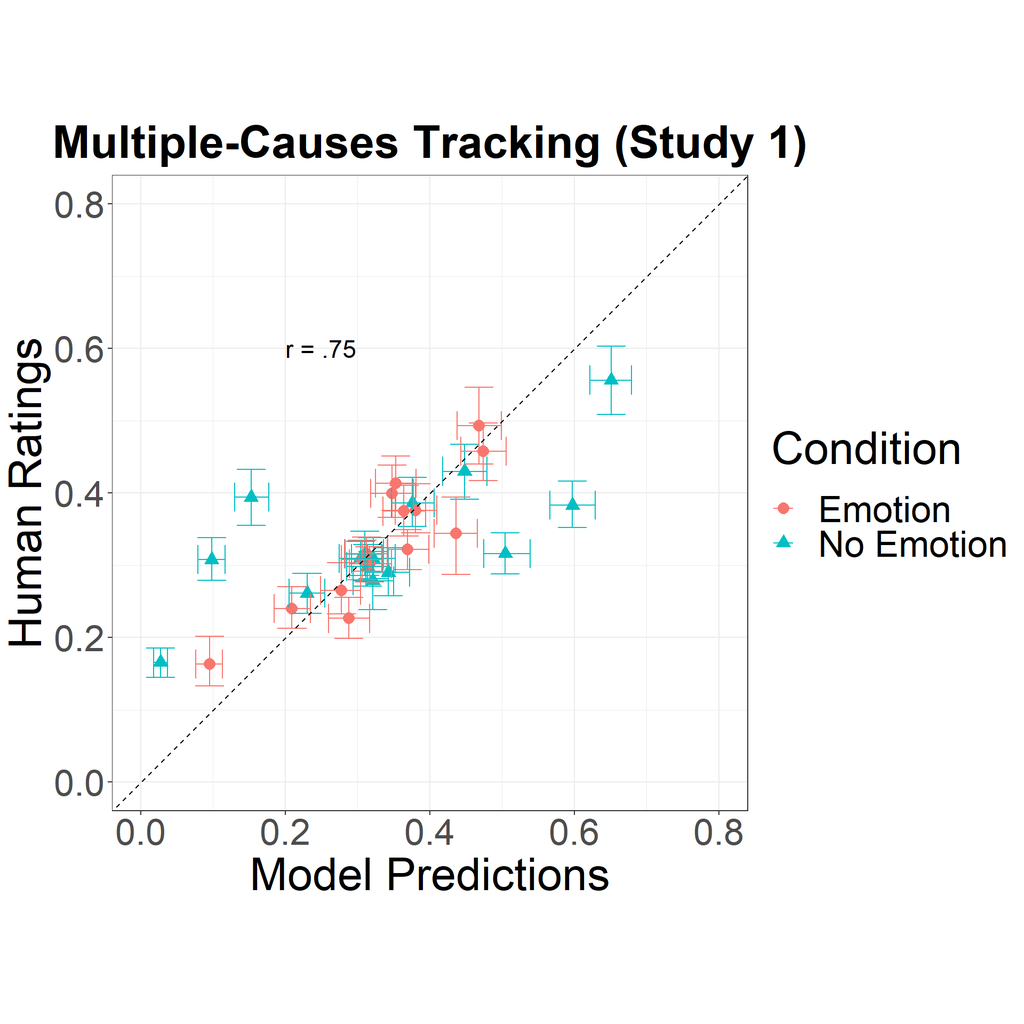

```r
corplot_tracking <- ggplot(cor_data, aes(x = pred, y = actual, color = Condition, shape = Condition))+
  geom_point(size=3.5) +
  geom_errorbar(data = cor_data, aes(x = pred, ymin=actual_lower, ymax=actual_upper), width = .04, size = .4)+
  geom_errorbarh(data = cor_data, aes(y = actual, xmin=pred_lower, xmax=pred_upper), height = .04, size = .4)+
  geom_abline(intercept = 0, slope = 1,linetype = 2) +
  xlim(0, .8) +
  ylim(0,.8)+
  coord_fixed(ratio = 1)+
  ylab("Human Ratings")+
  xlab("Model Predictions")+
  ggtitle("Multiple-Causes Tracking (Study 1)")+
  theme_bw()+
    theme(text = element_text(size = 32),
        plot.title = element_text(face = "bold", size = 32, hjust = 0.5)) +
  annotate("text", x=.25, y=.6, label= "r = .75", size = 6)

corplot_tracking
```

## 4.2 Plotting Human-Model Comparisons across Measurement Points

The line graphs below compares our model’s predictions on causal inference against mean participants’ ratings (normalized) of 3 causal hypotheses (“blue box”, “orange box”, “both boxes”) at 5 different key moments of the multiple-causes scenario. Graphs for the emotion condition are shown on the top row, whereas graphs for the no-emotion condition are illustrated on the bottom row. The error bars represent 95% confidence intervals.

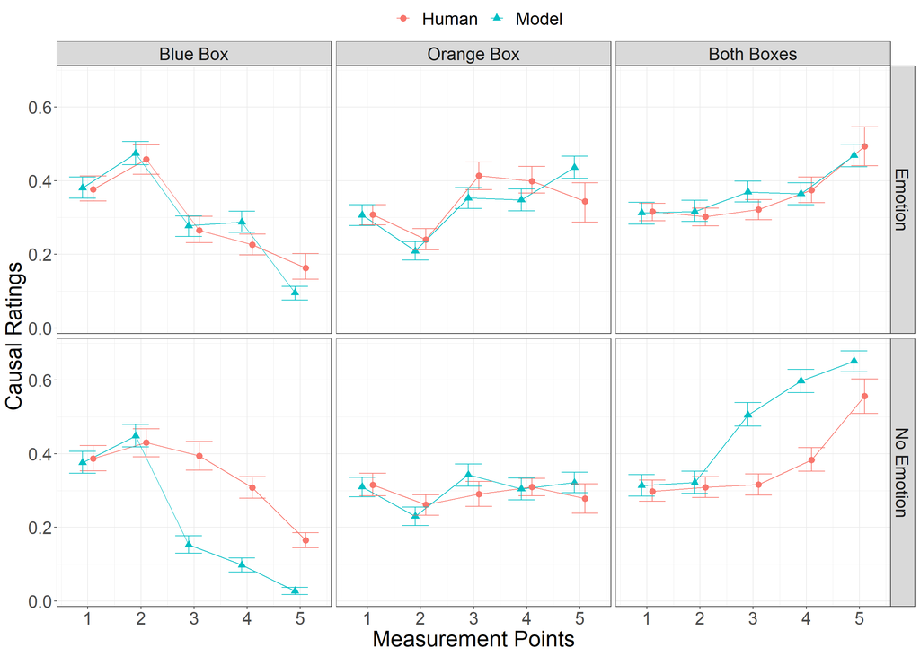

```r
tracking.plot <- ggplot(data=cause_time_data, aes(x=time, y=mean, group=Subject, color=Subject, shape=Subject)) +
  geom_line() +
  geom_point(size=3)+
  geom_errorbar( data = cause_time_data, aes(x = time,ymin=ci_lower, ymax=ci_upper, group=Subject), width = .5, size = .5)+
  facet_grid(~Condition ~Structure)+
  xlab("Measurement Points")+
  ylab("Causal Ratings")+
  theme_bw() +
  theme(text = element_text(size = 24),
        plot.title = element_text(face = "bold", size = 24, hjust = 0.5),
        legend.position = "top",
        legend.title=element_blank())
tracking.plot
```